# Analysis A3_2: PMM classification of HRS Core 2016 to 2022

Douglas Tommet and Richard N. Jones

2026-10-22

This analysis applies the profile mixture model (PMM) from Analysis A3 to the HRS Core samples of 2016, 2018, 2020, and 2022. We treat the model as a scoring machine. Every parameter, including the class proportions, is fixed at the value estimated in HRS/HCAP 2016. The model returns, for each person-wave, the probability of membership in the Normal, MCI, and Dementia classes. It has 2 parts: the cognition model (the 8 cognitive tests of the core interview and self-rated memory, with a general cognitive factor) and the informant model (the Jorm IQCODE). The sample is all respondents interviewed in a wave who were age 65 or older at that wave. Person-waves with an IQCODE are scored with the informant model and the others with the cognition model; the 6 person-waves (0.0%) with no IQCODE and no cognition-model input are not scored. The output file is `R_objects/A3_2_pmm_probs_hrs16_22.rds` (and `.dta`), with one row per person-wave.

## Input variables by wave

The table summarizes each model input among scored person-waves. Inputs come from the Analysis A0 wave-specific recodes, renamed to the Analysis A3 model names. Binary inputs show the percent coded 1. Other inputs show the mean (SD). The Jorm IQCODE is collected only when a proxy informant answers for the respondent.

| Variable | 2016 | 2018 | 2020 | 2022 |
| --- | --- | --- | --- | --- |
| Person-waves, N | 9,972 | 8,994 | 8,985 | 8,285 |
| Age, years | 75.96 (7.71) | 75.85 (7.77) | 75.48 (7.79) | 75.45 (7.85) |
| Female | 59.4% | 59.1% | 59.1% | 59.3% |
| Black (not Hispanic) | 16.2% | 17.5% | 17.9% | 19.7% |
| Hispanic | 11.2% | 12.6% | 13.8% | 14.7% |
| Years of schooling (imputed) | 12.63 (3.27) | 12.76 (3.29) | 12.90 (3.26) | 13.00 (3.26) |
| Orientation to time (0-4) | 3.63 (0.76) | 3.61 (0.77) | 3.68 (0.68) | 3.64 (0.72) |
| Animal naming (rescaled) | 0.17 (0.08) | 0.19 (0.10) | 0.19 (0.10) | 0.19 (0.08) |
| Object naming (0-2) | 1.90 (0.32) | 1.90 (0.33) | 1.91 (0.31) | 1.91 (0.31) |
| President/vice-president naming (0-2) | 1.61 (0.55) | 1.47 (0.61) | 1.63 (0.55) | 1.60 (0.62) |
| Delayed word recall (rescaled) | 0.39 (0.21) | 0.41 (0.20) | 0.42 (0.22) | 0.41 (0.21) |
| Number series (rescaled) | 0.61 (0.19) | not administered | 0.63 (0.19) | 0.65 (0.20) |
| Serial sevens (0-5) | 3.30 (1.77) | 3.38 (1.76) | 3.48 (1.72) | 3.42 (1.74) |
| Backward counting from 20 (0/1) | 91.8% | 91.6% | 91.8% | 91.1% |
| Memory compared to 2 years ago (1-3) | 2.24 (0.48) | 2.23 (0.47) | 2.20 (0.46) | 2.22 (0.47) |
| Jorm IQCODE (proxy informant) | 3.72 (0.83) | 3.69 (0.78) | 3.68 (0.78) | 3.72 (0.80) |

## Missing data in the model inputs

The table shows the percent of scored person-waves missing each input. “Not administered” marks an input that is absent from that wave’s Core data or missing for every respondent in that wave. These data are missing by design. Mplus treats these inputs as missing, and the model scores each respondent from the remaining inputs. Person-waves missing a covariate cannot be scored, because the model conditions the cognitive tests on the covariates. Person-waves with no cognitive test score, no self-rating of memory, and no IQCODE have no model input and are not scored. 0 person-waves have both an IQCODE and a cognition-model input; they are scored with the informant model, as in Analysis A3. The bottom rows show which model scored each person-wave.

| Variable | 2016 | 2018 | 2020 | 2022 |
| --- | --- | --- | --- | --- |
| Age, years | 0.0% | 0.0% | 0.0% | 0.0% |
| Female | 0.0% | 0.0% | 0.0% | 0.0% |
| Black (not Hispanic) | 0.0% | 0.0% | 0.0% | 0.0% |
| Hispanic | 0.0% | 0.0% | 0.0% | 0.0% |
| Years of schooling (imputed) | 0.0% | 0.0% | 0.0% | 0.0% |
| Orientation to time (0-4) | 7.3% | 14.9% | 19.2% | 17.9% |
| Animal naming (rescaled) | 7.9% | 16.8% | 19.2% | 18.4% |
| Object naming (0-2) | 7.3% | 14.9% | 19.2% | 17.9% |
| President/vice-president naming (0-2) | 7.3% | 14.9% | 19.2% | 17.9% |
| Delayed word recall (rescaled) | 7.9% | 15.9% | 19.9% | 19.3% |
| Number series (rescaled) | 20.5% | not administered | 18.8% | 52.5% |
| Serial sevens (0-5) | 7.3% | 5.7% | 6.5% | 5.7% |
| Backward counting from 20 (0/1) | 7.7% | 15.4% | 19.5% | 18.2% |
| Memory compared to 2 years ago (1-3) | 7.4% | 5.8% | 6.8% | 5.9% |
| Jorm IQCODE (proxy informant) | 92.8% | 94.3% | 93.5% | 94.3% |
| Scored with cognition model, N | 9,249 | 8,481 | 8,403 | 7,814 |
| Scored with Jorm model, N | 721 | 512 | 581 | 469 |
| Not scored, N | 2 | 1 | 1 | 2 |

**Number series.** The HRS Core does not include the number series test in every wave, so its absence in some waves is by design. In the scored person-waves, number series scores are not available in 2018, and are present in 2016, 2020, 2022. The HCAP 2016 calibration model includes number series. Person-waves without it are scored from the other cognitive tests and self-rated memory. Their class probabilities rest on less information than those of person-waves with a number series score.

## Class probabilities across waves

The next three pages show one class each. Each matrix plots the same respondents’ probit-transformed class probability, z = Φ⁻¹(p), across the four waves. A point appears in a panel when the respondent was scored in both waves. For display, probabilities are bounded to [0.0005, 0.9995] before the transform; the exported probabilities retain twelve decimal places. This bounds z at ±3.29, and points at the bounds mark respondents classified with near certainty. The table under each matrix gives Pearson correlations below the diagonal, the number of respondents scored in both waves above the diagonal, and the number scored in each wave on the diagonal.

### P(Normal)

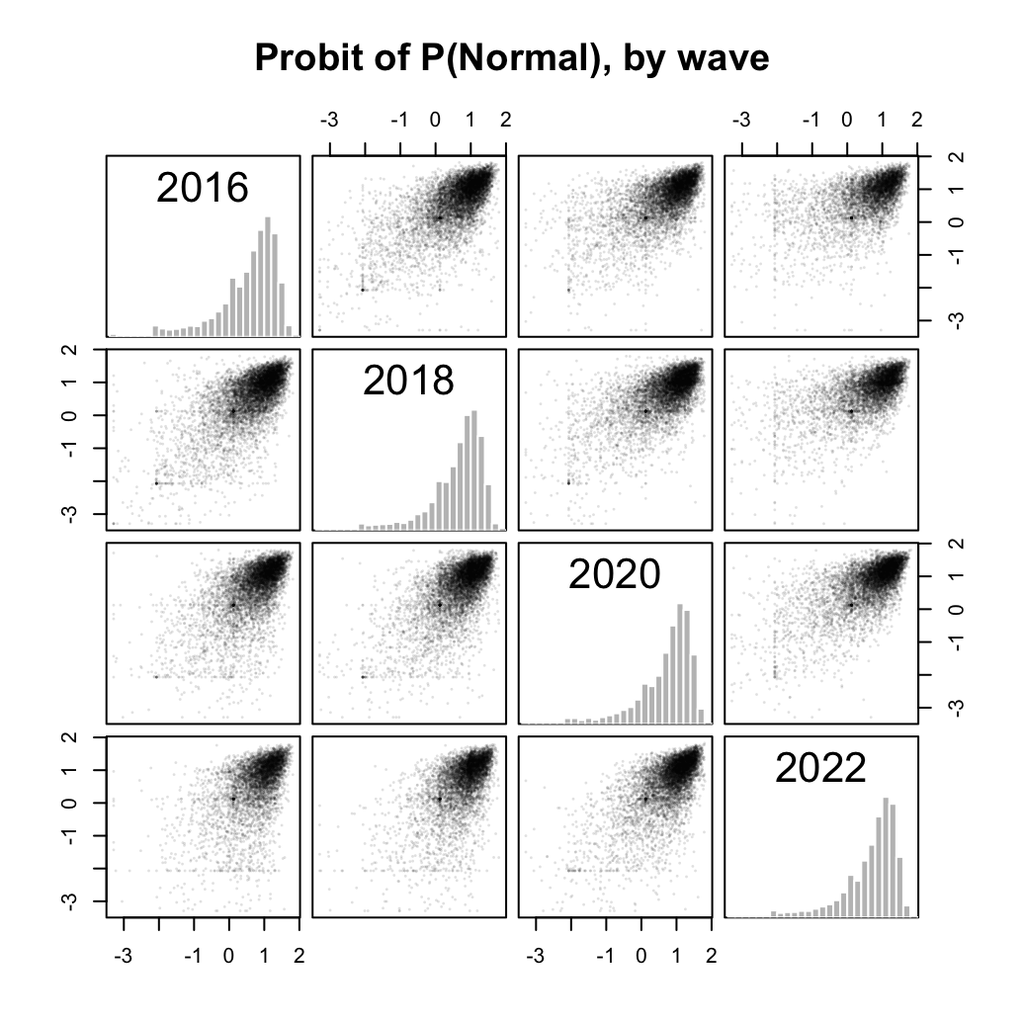

|  | 2016 | 2018 | 2020 | 2022 |
| --- | --- | --- | --- | --- |
| 2016 | 9,970 | 7,779 | 6,648 | 5,256 |
| 2018 | 0.69 | 8,993 | 7,288 | 5,866 |
| 2020 | 0.63 | 0.67 | 8,984 | 6,856 |
| 2022 | 0.55 | 0.60 | 0.68 | 8,283 |

### P(MCI)

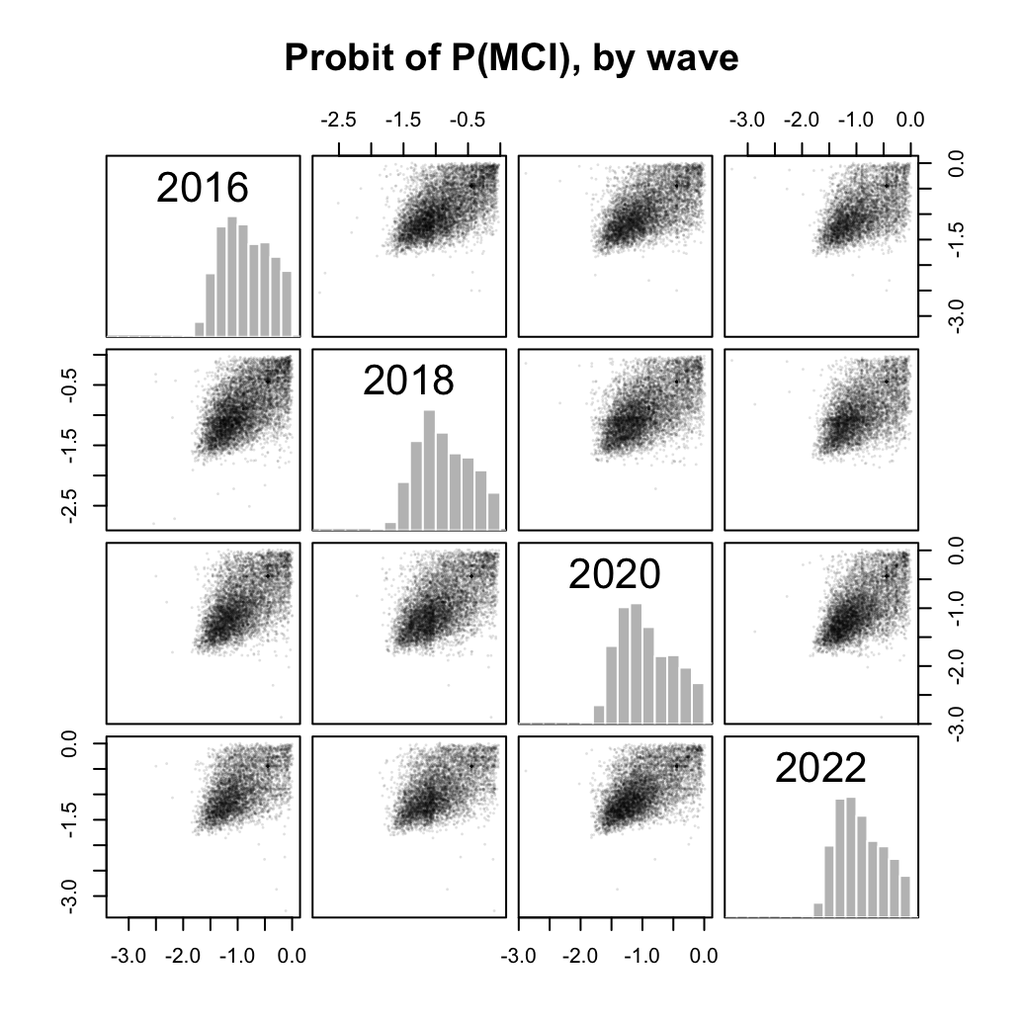

|  | 2016 | 2018 | 2020 | 2022 |
| --- | --- | --- | --- | --- |
| 2016 | 9,970 | 7,779 | 6,648 | 5,256 |
| 2018 | 0.58 | 8,993 | 7,288 | 5,866 |
| 2020 | 0.57 | 0.57 | 8,984 | 6,856 |
| 2022 | 0.51 | 0.53 | 0.59 | 8,283 |

### P(Dementia)

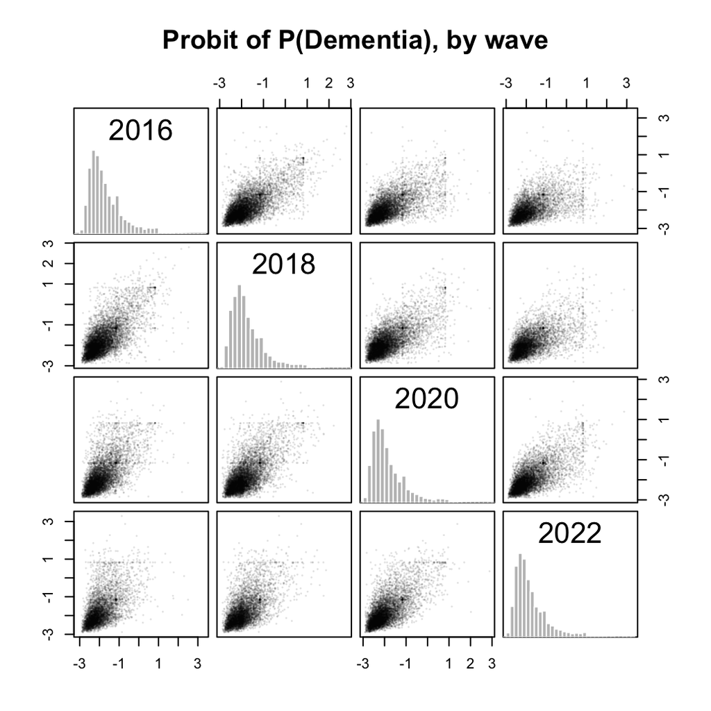

|  | 2016 | 2018 | 2020 | 2022 |
| --- | --- | --- | --- | --- |
| 2016 | 9,970 | 7,779 | 6,648 | 5,256 |
| 2018 | 0.69 | 8,993 | 7,288 | 5,866 |
| 2020 | 0.64 | 0.67 | 8,984 | 6,856 |
| 2022 | 0.55 | 0.60 | 0.69 | 8,283 |

## Check: HCAP 2016 reproduction of Analysis A3

Analysis A3 scored the HRS/HCAP 2016 participants from Analysis A1 inputs. This analysis scores the same people from Analysis A0 inputs with the same fixed model. If the two pipelines code the inputs the same way, the probabilities agree. The first table compares the probabilities. The second compares each input among participants observed in both pipelines.

| Statistic | Value |
| --- | --- |
| HCAP participants in Analysis A3 | 3,496 |
| Matched in Analysis A0 2016 file | 3,470 |
| Scored in both | 3,470 |
| Same model used (cognition or Jorm), % | 100.0 |
| Largest class difference < 0.001, % | 99.9 |
| Largest class difference < 0.01, % | 100.0 |
| Largest class difference, maximum | 0.0309 |
| Correlation, P(Normal) | 1.0000 |
| Correlation, P(MCI) | 1.0000 |
| Correlation, P(Dementia) | 1.0000 |
| Same modal class, % | 100.0 |

| Input | N in both | Identical, % | Max difference | Missing in A1 only | Missing in A0 only |
| --- | --- | --- | --- | --- | --- |
| vdori | 3257 | 100.0 | 0.0000 | 0 | 0 |
| vdlfl1z | 3247 | 100.0 | 0.0000 | 0 | 0 |
| vdlfl2 | 3257 | 100.0 | 0.0000 | 0 | 0 |
| vdlfl3 | 3257 | 100.0 | 0.0000 | 0 | 0 |
| vdwddelz | 3247 | 100.0 | 0.0000 | 0 | 0 |
| vdexf7z | 2852 | 100.0 | 0.0000 | 0 | 0 |
| vdsevens | 3257 | 100.0 | 0.0000 | 0 | 0 |
| vdcount | 3250 | 100.0 | 0.0000 | 0 | 0 |
| PD102 | 3254 | 100.0 | 0.0000 | 0 | 0 |
| jorm | 213 | 100.0 | 0.0000 | 0 | 0 |
| x1 | 3470 | 100.0 | 0.0000 | 0 | 0 |
| x2 | 3470 | 100.0 | 0.0000 | 0 | 0 |
| x3 | 3470 | 100.0 | 0.0000 | 0 | 0 |
| x4 | 3470 | 100.0 | 0.0000 | 0 | 0 |
| x5 | 3470 | 100.0 | 0.0000 | 0 | 0 |
| x6 | 3470 | 100.0 | 0.0000 | 0 | 0 |
| x7 | 3470 | 99.9 | 3.0000 | 0 | 0 |
| x4x5 | 3470 | 100.0 | 0.0000 | 0 | 0 |
| x4x6 | 3470 | 100.0 | 0.0000 | 0 | 0 |